# Module Seven Activity

For the module seven activity, you will identify relevant data and write Python code to generate visualizations and interpret insights from the provided data set. Professionals in data-driven fields must not only interpret data but also gather, analyze, and present it in meaningful and actionable ways. This activity allows you to practice these essential skills by working through the complete exploratory data analysis (EDA) process.

*Note:* there are two parts to this assignment. Part One is the coding activity. Part Two is the written report.

Once your code is complete, you will download this notebook as an HTML file by clicking **File**, then **Download As**, then **HTML (.html)** from the Jupyter menu bar. Validate that your code, output, and all visualizations (rendered as images using the display() function) are visible in the html file before submission.

*Missing Blocks:* Ensure that you have clicked **Run** for all blocks before downloading as an HTML file or the block may be missing from your submission. **Images** must be called using the *display()* function, for example: **display(Image(filename="output/{image_name}.png"))**

Specifically, you must address the items from the rubric criteria.

### Part One: Python Code

In this part, you will write Python code to analyze the data and generate visualizations that explore trends.

#### Create multiple, distinct visualizations that explore different aspects of the data using Python Libraries.

Include the following:

- Code comments explaining each step of your analysis

### Part Two: Report

In this part, you will write a reflection to explain the insights gained from your analysis and visualizations. *This part is to be completed in a word document, using the output here to answer the topics.*

- Explain the trends, differences, or outliers you observed in the data.
- Describe any disparities or patterns that may be relevant to the nonprofit’s goals.
- Write a summary of what the data suggests about transit usage across neighborhoods.
- Explain how the visualizations support your conclusions.
- Discuss how your findings could inform the nonprofit’s decision-making or strategy.
- Describe the importance of data-driven insights in addressing real-world challenges.

*To Begin:* This Python template program has been broken down into segments as a guide for what steps you should do at a minimum to complete this activity. Look for the **# To Do:** comments. These are placeholders for you to provide Python code segments. Fill out all **# To Do:** code segments to complete this program.  
*Once Complete:* Execute a "Kernel restart and run all" to verify that all your code works as a single unit by clicking **Kernel**, then **Restart & Run All** before downloading as html.

*Hint:* If you need to install additional packages, see one of the earlier modules on how to configure and call a requirements.txt file.

## Import the Required Packages

```python
import pandas as pd
import matplotlib.pyplot as plt
import seaborn as sns
import os
import matplotlib.image as mpimg

from IPython.display import Image, display # for image rendering in html output
```

# Part One: Python Code

*Reminder:* Ensure that you add code comments explaining each step of your analysis.

## Define the file path for the dataset

```python
data_path = "data/Feb_2025_Complete_Monthly_Ridership.csv"
```

## Loading the dataset

```python
# To Do: Load the dataset

#Loading the CSV file into a pandas DataFrame
df = pd.read_csv(data_path)

#Checks to ensure that the basic info is there and that everything loaded properly.
print("Shape of the dataset: ", df.shape)
print("\nData types: ")
print(df.dtypes)
```

```
Shape of the dataset:  (2311, 27)

Data types:
NTD ID                           int64
Legacy NTD ID                   object
Agency                          object
Mode                            object
TOS                             object
3 Mode                          object
Mode/Type of Service Status     object
Reporter Type                   object
Organization Type               object
HQ City                         object
HQ State                        object
UACE CD                        float64
UZA Name                        object
UZA SQ Miles                   float64
UZA Population                 float64
Service Area Population        float64
Service Area SQ Miles          float64
Last Closed Report Year        float64
Last Closed FY End Month       float64
Last Closed FY End Year        float64
Passenger Miles FY              object
Unlinked Passenger Trips FY     object
Avg Trip Length FY             float64
Fares FY                        object
Operating Expenses FY           object
Avg Cost Per Trip FY            object
Avg Fares Per Trip FY           object
dtype: object
```

## Create an output folder if it doesn't already exist

```python
output_folder = "output"
os.makedirs(output_folder, exist_ok=True)
```

## Display Dataset Information

```python
print("Dataset Overview:")
# To Do: Print the first 5 rows of the dataset to inspect the data to ensure it loaded correctly

#Shows the first five rows of the dataset to confirm that it loaded as expected. This is a more detailed version
#of what was done earlier that confirms the types of data present.
print(df.head())
```

```
Dataset Overview:
   NTD ID Legacy NTD ID       Agency Mode TOS 3 Mode
0       1          0001  King County   DR  PT    Bus  \
1       1          0001  King County   DR  TX    Bus
2       1          0001  King County   FB  DO  Ferry
3       1          0001  King County   LR  DO   Rail
4       1          0001  King County   MB  DO    Bus

  Mode/Type of Service Status  Reporter Type
0                      Active  Full Reporter  \
1                      Active  Full Reporter
2                      Active  Full Reporter
3                    Inactive  Full Reporter
4                      Active  Full Reporter

```

[output cut: 36 more lines]

```python
print("Column Names:")
# To Do: Print all column names

#This displays all of the column names to help in understanding what fields are available.
print(df.columns.tolist())
```

```
Column Names:
['NTD ID', 'Legacy NTD ID', 'Agency', 'Mode', 'TOS', '3 Mode', 'Mode/Type of Service Status', 'Reporter Type', 'Organization Type', 'HQ City', 'HQ State', 'UACE CD', 'UZA Name', 'UZA SQ Miles', 'UZA Population', 'Service Area Population', 'Service Area SQ Miles', 'Last Closed Report Year', 'Last Clo…
```

```python
neighborhoods = ["King County", "City of Longview", "Spokane Transit Authority"]
# To Do: Filter the data for the three neighborhoods and create an explicit copy

#This filters the rows where the agency/neighborhood is one of the three listed as being of interest.
filtered_df = df[df["Agency"].isin(neighborhoods)].copy()

print("\nFiltered dataset shape: ", filtered_df.shape)
print(filtered_df["Agency"].value_counts())
```

```
Filtered dataset shape:  (17, 27)
Agency
King County                  9
Spokane Transit Authority    4
City of Longview             4
Name: count, dtype: int64
```

```python
# To Do: Convert numeric columns to proper formats (removing commas and extra spaces)

# The list of columns that should be numeric.
numeric_cols = [
    "UZA SQ Miles",
    "UZA Population",
    "Service Area Population",
    "Service Area SQ Miles",
    "Passenger Miles FY",
    "Unlinked Passenger Trips FY",
    "Avg Trip Length FY",
    "Fares FY",
    "Operating Expenses FY",
    "Avg Cost Per Trip FY",
    "Avg Fares Per Trip FY"
]

# This converts the numeric columns, removes commas, strips spaces and converts to float.
for col in numeric_cols:

    if col in filtered_df.columns:

        filtered_df[col] = (filtered_df[col]
            .astype(str)
            .str.replace(",", "", regex=False)
            .str.strip())

        filtered_df[col] = pd.to_numeric(filtered_df[col], errors = "coerce")

print("\nData types after conversion:")
print(filtered_df.dtypes)
```

```
Data types after conversion:
NTD ID                           int64
Legacy NTD ID                   object
Agency                          object
Mode                            object
TOS                             object
3 Mode                          object
Mode/Type of Service Status     object
Reporter Type                   object
Organization Type               object
HQ City                         object
HQ State                        object
UACE CD                        float64
UZA Name                        object
UZA SQ Miles                   float64
UZA Population                 float64
Service Area Population        float64
Service Area SQ Miles          float64
Last Closed Report Year        float64
Last Closed FY End Month       float64
Last Closed FY End Year        float64
Passenger Miles FY               int64
Unlinked Passenger Trips FY      int64
Avg Trip Length FY             float64
Fares FY                       float64
Operating Expenses FY          float64
Avg Cost Per Trip FY           float64
Avg Fares Per Trip FY          float64
dtype: object
```

## Generate, Save, and Output Visualizations

*Example Visualizations:* The three visualization placeholders below are example visualization placeholders for the data using a provided template. These are simple example frameworks that you may use, but you may, and are encouraged to develop your own visualizations that you will then explain how the selected visualizations support your conclusions in the part two report.

In accordance with the scenario, three neighborhoods for evaluation are: King County, City of Longview, and Spokane Transit Authority which have been listed in the neighborhoods variable above.

### Visualization 1: Line chart of ridership trends over years

This is an example visualization you can generate. You may implement a chart and assessment of your choosing in lieu of this placeholder.

#### At a minimum include the following actions:

- Add title and axis labels
- Save the plot to a png file in the 'output' folder
- Use the display() function to render the generated png image in the html output
- Comments explaining each step of your analysis

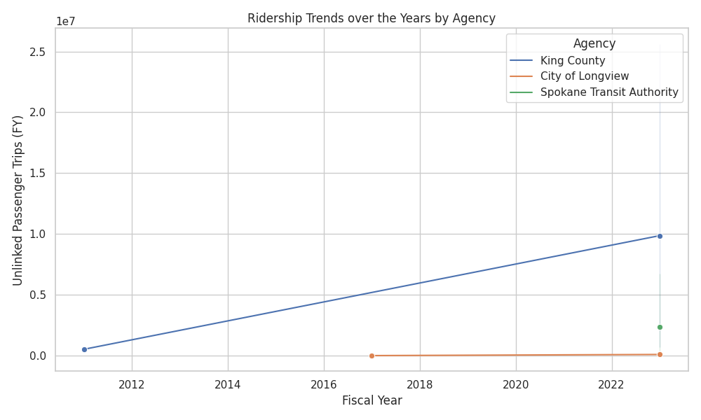

```python
# To Do: Create a visualization that will support your conclusions for part two

#Ensures that the year column is numeric.
filtered_df["Last CLose FY End Year"] = pd.to_numeric(filtered_df["Last Closed FY End Year"], errors = "coerce")

#Sorts the values to make the line chart be ordered by year.
filtered_df_sorted = filtered_df.sort_values("Last Closed FY End Year")

#Sets the plot style.
sns.set(style = "whitegrid")

#Creates the line plot.
plt.figure(figsize = (10, 6))

#Plots the ridership over time for each agency.
sns.lineplot(data = filtered_df_sorted,
            x = "Last Closed FY End Year",
            y = "Unlinked Passenger Trips FY",
            hue = "Agency",
            marker = "o")

#Adds the title and axis labels.
plt.title("Ridership Trends over the Years by Agency")
plt.xlabel("Fiscal Year")
plt.ylabel("Unlinked Passenger Trips (FY)")

#A tight layout for better spacing.
plt.tight_layout()

#Saves the figure to the output folder
viz1_path = os.path.join(output_folder, "viz1_ridership_trends.png")
plt.savefig(viz1_path)

#Closes the plot to avoid duplicate displays in some environments.
plt.close()

#Displays the saved image in the notebook/HTML output.
display(Image(filename = viz1_path))
```

### Visualization 2: Bar chart comparing total ridership across neighborhoods

This is an example visualization you can generate. You may implement a chart and assessment of your choosing in lieu of this placeholder.

#### At a minimum include the following actions:

- Add title and axis labels
- Save the plot to a png file in the 'output' folder
- Use the display() function to render the generated png image in the html output
- Comments explaining each step of your analysis

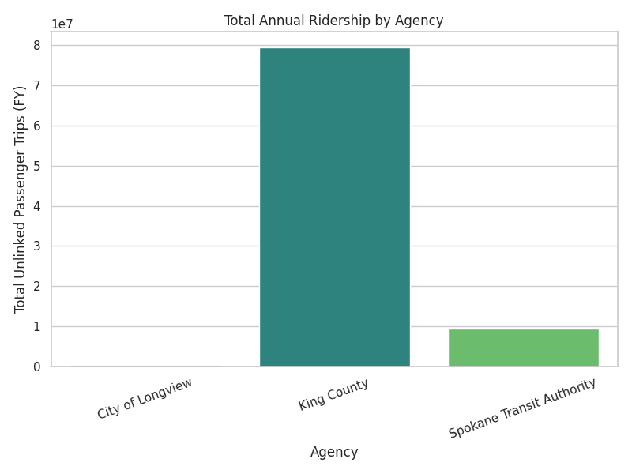

```python
# To Do: Create a visualization that will support your conclusions for part two

# Groups by the agency and sums up the annual ridership.
ridership_by_agency = (filtered_df
    .groupby("Agency", as_index = False)["Unlinked Passenger Trips FY"]
    .sum())

# Creates the bar plot.
plt.figure(figsize = (8, 6))

sns.barplot(data = ridership_by_agency,
    x = "Agency",
    y = "Unlinked Passenger Trips FY",
    palette = "viridis")

# Rotates x labels for readability.
plt.xticks(rotation = 20)

# Adds title and axis labels.
plt.title("Total Annual Ridership by Agency")
plt.xlabel("Agency")
plt.ylabel("Total Unlinked Passenger Trips (FY)")

plt.tight_layout()

# Saves the figure
viz2_path = os.path.join(output_folder, "viz2_ridership_by_agency.png")
plt.savefig(viz2_path)
plt.close()

# Displays the saved image
display(Image(filename = viz2_path))
```

### Visualization 3: Scatterplot of ridership vs population

This is an example visualization you can generate. You may implement a chart and assessment of your choosing in lieu of this placeholder.

#### At a minimum include the following actions:

- Add title and axis labels
- Save the plot to a png file in the 'output' folder
- Use the display() function to render the generated png image in the html output
- Comments explaining each step of your analysis

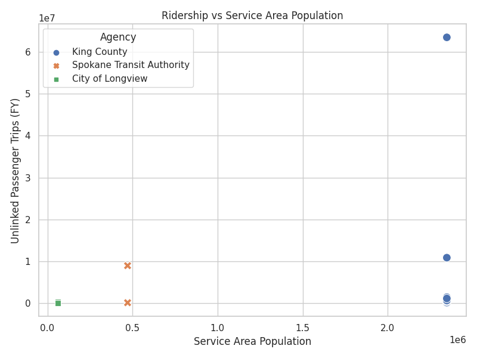

```python
# To Do: Create a visualization that will support your conclusions for part two

# Creates the scatter plot.
plt.figure(figsize = (8, 6))

sns.scatterplot(data = filtered_df,
    x = "Service Area Population",
    y = "Unlinked Passenger Trips FY",
    hue = "Agency",
    style = "Agency",
    s = 100)

# Adds title and axis labels.
plt.title("Ridership vs Service Area Population")
plt.xlabel("Service Area Population")
plt.ylabel("Unlinked Passenger Trips (FY)")

plt.tight_layout()

# Saves the figure
viz3_path = os.path.join(output_folder, "viz3_ridership_vs_population.png")
plt.savefig(viz3_path)
plt.close()

# Displasy the saved image
display(Image(filename = viz3_path))
```